# Notebook 04. External Evidence — 맥락과 교차확인

## 이 단계의 질문

Triage 및 선택적 재검토로 확인된 사례가 다른 외부자료에서도 설명 또는 확인되는가?

## 이전 단계에서 확인한 것

Notebook 03에서 CORE와 Triage는 확인 순서를 정하지만 원인을 설명하지 못하며, ELECTRE/SMAA도 그 한계를 해결하지 못함을 확인했다.

## 이번 단계에서 하는 것

PPI·EIS·업체수·가동률·관세청·KEPCO·KOSIS·ECOS·고용24의 실제 가용성, 범위, 업종 정합성, 최신성, 역할을 구분하고 최신 주요 사례의 맥락을 확인한다.

## 이번 단계에서 하지 않는 것

외부자료로 CORE/Triage 단계를 덮어쓰거나 서로 다른 모집단의 신호를 합산해 새 점수를 만들지 않는다.

## 증거의 위치

```
CORE
  ↓
Triage
  ↓ (추가확인일 때만)
Selective ELECTRE/SMAA
  ↓
External Evidence  ── 판정 변경 X / 맥락·원인후보·확인질문 보강 O
```

```
현재 자료 역할 15종 | 최신 외부근거 10개 업종 | latest=2026Q2
```

## 1. 데이터 가용성·역할 표

`CORE`는 판정의 직접 입력, `VALIDATION`은 방향·측정 한계의 제한적 교차검증, `CONTEXT`는 원인후보와 현장 질문을 보강하는 자료, `EXCLUDE`는 현재 판정에 사용할 수 없는 자료다. “파일이 있다”와 “이번 업종×분기 판정 근거로 쓸 수 있다”를 구분한다.

| 자료 | 역할 | 직접 측정 | 가능한 사용 | 말할 수 없음 | 기간·공간·업종·품질 제약 | 파일 존재 | 판정 근거 사용 |
| --- | --- | --- | --- | --- | --- | --- | --- |
| KICOX 창원국가산단 업종별 생산 | CORE | 업종별 명목 생산액 | 생산 방향·변화율 | 실질 생산량이나 가격효과의 원인 | 가격효과가 섞이고 일부 공표구간은 보정본 | True | 예 |
| KICOX 창원국가산단 업종별 고용 | CORE | 산단 입주기업 종사자 수 | 고용 증감·비중·기여 | 실업·이직·직무 미스매치의 원인 | 분기말 집계이며 기업별 분포는 없음 | True | 예 |
| KICOX 가동률 | CONTEXT | 산단 가동률 | 조업 위축 여부 | 생산량·전력량·휴업 원인 | 2024Q2 전후 정의 단절 구간 존재 | True | 아니오(맥락만) |
| KICOX 입주업체·가동업체 | CONTEXT | 입주·가동 업체 수 | 업체 구성·가동상태 변화 | 폐업·퇴거·합병 등 개별 사건 | 소규모 업종은 비율 변동이 큼 | True | 아니오(맥락만) |
| 생산자물가지수(PPI) | VALIDATION | 전국 품목별 생산자가격 | 명목 생산변화의 가격효과 가능성 | 창원산단 실질생산량 | 전국지수·업종 매핑 A~D 혼재 | True | 제한적 교차확인 |
| EIS 및 창원상의 고용보험 피보험자 | VALIDATION | 창원시 고용보험 피보험자 | KICOX 고용 방향의 제한적 교차확인 | 산단 고용 수준·점유율 또는 전체 10업종 | 창원시 전역; 업종 비교는 3개 업종·21행 | True | 제한적 교차확인 |
| 관세청 창원시 HS6 수출입 | CONTEXT | 확인된 HS6 품목의 창원시 통관액 | 외부수요 방향 | 업종 총수출 또는 산단 수출 | 창원시 전역·부분 품목·HS→업종 매핑 | True | 아니오(맥락만) |
| KEPCO 기존 businessType 전력 | CONTEXT | 창원시/5개 구 전력사용량 | 조업활동 보조 방향 | 산단 생산량 또는 정확한 KICOX 업종 전력 | 비공식 업종분류, 산단 경계 아님, 방향 일치 50~55% | True | 아니오(맥락만) |
| KEPCO 법정동×KSIC 전력 | CONTEXT | 18개 제조업 집적 법정동의 공개 셀 전력 | 공간·업종별 조업 맥락 | 산단 또는 업종 전체 전력사용량 | 2022-04~2026-03, 비식별 40.47%, 업종합계 COMPLETE 0, 2026Q2 없음 | True | 아니오(맥락만) |
| 고용24 창원·마산 고용복지+센터 공개 채용정보(Work24 canonical) | CONTEXT | 수집시점에 게시 중이던 공개 채용공고(창원시 5개 구 2,045건, 2026-09-19 단면) | 판정 이후 해당 업종에서 어떤 기업이 어떤 직무를 공개채용 중인지 확인하는 단서 | 고용 증가, 업종별 채용수요 규모, 구인율, 과거 추세, 모집인원 | 등록일 2026-07-21~09-18 의 2026Q3 단일분기로 모형 최종시점 2026Q2 와 overlap 0; recruitment_count 0%; KICOX 매핑 663/2,045(기업매칭 성립분에 한정); 구별 기업매칭률 14.4~43.2% 선택편향; 산업단지 MATCH 0(POSSIBLE 은 소재 확정 아님); 60일 롤링 게시창에 따른 생존편향 | True | 아니오(맥락만) |
| KOSIS 사업체노동력조사 입직·이직·빈일자리 | CONTEXT | 창원시 제조업 총계 반기 노동이동 | 채용둔화·이직증가의 지역 배경 | KICOX 업종별 고용 증감 | 표본조사·반기·제조업 총계 | True | 아니오(맥락만) |
| 한국은행 경남·전국 업종 BSI | CONTEXT | 경남 제조업 및 전국 업종 심리 | 지역·전국 경기 배경 | 창원산단 업종의 실적 | 경남은 업종 없음, 업종은 전국; 행 단위 변별력 낮음 | True | 아니오(맥락만) |
| 창원시 공장등록현황 | CONTEXT | 창원시 공장 단일시점 구성 | 법정동 제조업 집적 proxy | 업체수 증감·산단 기업 변동 | 2024-12-31 단일시점, 산단 내외 미분리 | True | 아니오(맥락만) |
| KEPCO 전기사용고객 증감 | EXCLUDE | 공식 화면상 신설·증설·해지 값 | 현재 없음 | 고객수·계약건수 | 공식 화면의 건수/KWH 정의 충돌 및 비정상 값 | True | 아니오 |
| 고용유지지원금·워크넷 집계·기타 미확보 후보 | EXCLUDE | 현재 직접 측정값 없음 | 현재 없음 | 업종 위험 또는 지원효과 | 공개 통계 부재·API 명세/과거 패널 미확보 | True | 아니오 |

```
{'CONTEXT': 9, 'CORE': 2, 'EXCLUDE': 2, 'VALIDATION': 2}
```

### 관찰

- KICOX 생산·고용만 CORE다. PPI와 EIS/창원상의는 VALIDATION이며, 수출입·전력·노동이동·BSI·고용24는 서로 다른 공간·빈도·업종단위의 CONTEXT다.
- KEPCO 법정동×KSIC는 비식별 40.47%, 완전한 업종분기 0건, 최신 2026Q2 없음이다. 고용24는 2026Q3 단면으로 모형 최신분기와 겹치지 않는다.

### 해석

- 확보된 데이터라도 업종×분기 정합성이 부족하면 자동 판정변수로 사용할 수 없다.

### 주의

- proxy의 방향 일치·불일치는 인과 확인이나 반증이 아니다.

## 2. PPI — 명목 생산과 가격조정 생산의 최신 비교

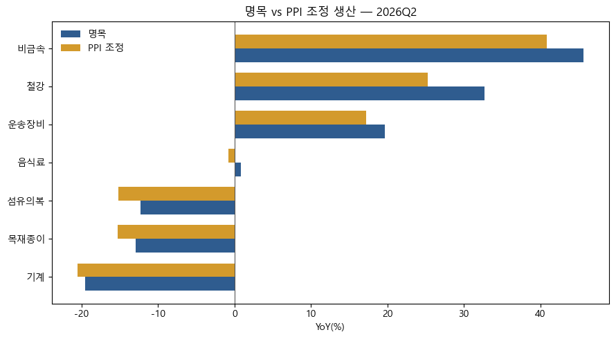

| industry | nominal_production_yoy | ppi_adjusted_production_yoy | ppi_mapping_grade |
| --- | --- | --- | --- |
| 기계 | -19.550000 | -20.550000 | A |
| 목재종이 | -12.900000 | -15.290000 | A |
| 섬유의복 | -12.320000 | -15.170000 | A |
| 음식료 | 0.870000 | -0.780000 | A |
| 운송장비 | 19.640000 | 17.240000 | A |
| 철강 | 32.650000 | 25.280000 | B |
| 비금속 | 45.670000 | 40.860000 | A |

관찰

- 최신분기에도 음식료처럼 명목과 PPI 조정 방향이 다른 사례가 있다. 기계·목재종이는 두 기준 모두 감소 방향이다.

해석

- PPI는 명목 생산 변화가 가격효과만으로 설명되지 않는지 점검하는 보조 근거다.

주의

- 전국 PPI의 업종 매핑은 창원산단 실질생산량이 아니며 등급 C/D는 단일값 해석을 제한한다.

## 3. EIS — 서로 다른 모집단의 고용 방향 교차확인

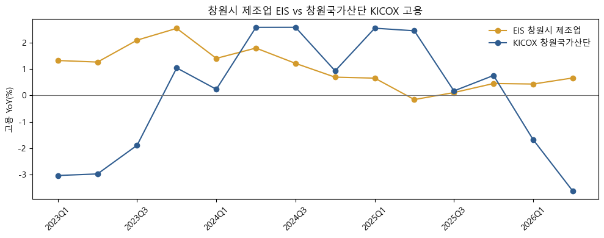

관찰

- 두 계열은 같은 지역 고용을 보지만 모집단이 창원시 전역과 국가산단으로 다르며 분기별 방향·크기가 항상 같지 않다.

해석

- 방향이 같을 때는 지역 고용 맥락을 보강하고, 다를 때는 산단 고유 변화인지 확인할 질문을 만든다.

주의

- EIS 제조업 총계로 KICOX 10개 업종의 개별 단계를 검증할 수 없다.

## 4. 최신 주요 사례의 외부근거

최신분기 추가확인은 0건이므로, 아래는 우선점검 2개 업종을 중심으로 본다. 과거 추가확인 35건의 ELECTRE/SMAA 결과는 Notebook 03에 보존했다.

| industry | quarter | stage | signal_profile | nominal_production_yoy | ppi_adjusted_production_yoy | trade_export_yoy | power_usage_yoy | bsi_region_business | bsi_industry_business | mfg_flow_job_openings | check_questions_context | handoff_review_functions |
| --- | --- | --- | --- | --- | --- | --- | --- | --- | --- | --- | --- | --- |
| 기계 | 2026Q2 | 우선점검 | 가동 위축 신호 · 실질생산 위축 신호(PPI 조정) | -19.547351 | -20.547175 | -38.098629 | 0.752596 | 74.670000 | 76.840000 | 513.000000 | 가동률 하락이 일시적 생산조정인지 수주·수요 감소에 따른 것인지 확인할 필요가 있다. 명목생산 변화에 가격효과가 포함되어 있으므로 실제 물량이 줄었는지 추가로 확인할 필요가 있다. 확인된 품목 기준 수출이 함께 감소하고 있어, 외부수요 약화 가능성을 보려면 수출 감소가 특정 품목·기업에 집중되는지 추가 확인할 필요가 있다. 창원시 제조업 전체에서 이직자 증… | 산업동향 · 기업지원 / 산업동향 / 고용지원 |
| 목재종이 | 2026Q2 | 우선점검 | 실질생산 위축 신호(PPI 조정) | -12.897128 | -15.289242 | nan | 0.752596 | 74.670000 | 59.660000 | 513.000000 | 명목생산 변화에 가격효과가 포함되어 있으므로 실제 물량이 줄었는지 추가로 확인할 필요가 있다. 창원시 제조업 전체에서 이직자 증가가 함께 관측되므로, 특정 사업장 조정 또는 노동이동과 관련된 것인지 추가 확인할 필요가 있다. 경남 제조업 업황 심리지수가 기준선(100)을 밑돌아, 업종 고유 요인인지 지역 전반의 경기 흐름인지 구분해 확인할 필요가 있다. 같… | 산업동향 / 고용지원 |

기계

**CORE/Triage.** 우선점검; 명목 생산 YoY -19.55%.

**External Evidence.** 가동 위축 신호 · 실질생산 위축 신호(PPI 조정). PPI 조정 생산은 -20.54717489973789%이다.

**해석.** 외부자료는 생산·가동·수요·지역고용의 맥락을 보강하지만, 서로 다른 범위 때문에 기업별 원인을 확정하지 않는다.

**추가 확인.** 가동률 하락이 일시적 생산조정인지 수주·수요 감소에 따른 것인지 확인할 필요가 있다. 명목생산 변화에 가격효과가 포함되어 있으므로 실제 물량이 줄었는지 추가로 확인할 필요가 있다. 확인된 품목 기준 수출이 함께 감소하고 있어, 외부수요 약화 가능성을 보려면 수출 감소가 특정 품목·기업에 집중되는지 추가 확인할 필요가 있다. 창원시 제조업 전체에서 이직자 증가가 함께 관측되므로, 특정 사업장 조정 또는 노동이동과 관련된 것인지 추가 확인할 필요가 있다. 가동률과 전력사용의 방향이 달라 업종 구성·설비 특성·자료범위(산단 vs 시 전체) 차이를 추가 확인할 필요가 있다. 경남 제조업 업황 심리지수가 기준선(100)을 밑돌아, 업종 고유 요인인지 지역 전반의 경기 흐름인지 구분해 확인할 필요가 있다. 같은 업종의 전국 업황 심리지수도 기준선을 밑돌아, 관측된 변화가 산단 고유 현상인지 전국 업종 흐름인지 확인할 필요가 있다. 이 분기는 월별 원자료가 공표되지 않아 분기 내 지속 여부를 확인할 수 없다. 분기말 단일시점 값에만 의존한 판단임을 감안할 필요가 있다. 연간보정 개정본을 사용한 구간이다. 이후 재개정 시 값이 달라질 수 있음을 확인할 필요가 있다.

목재종이

**CORE/Triage.** 우선점검; 명목 생산 YoY -12.90%.

**External Evidence.** 실질생산 위축 신호(PPI 조정). PPI 조정 생산은 -15.289242445913676%이다.

**해석.** 외부자료는 생산·가동·수요·지역고용의 맥락을 보강하지만, 서로 다른 범위 때문에 기업별 원인을 확정하지 않는다.

**추가 확인.** 명목생산 변화에 가격효과가 포함되어 있으므로 실제 물량이 줄었는지 추가로 확인할 필요가 있다. 창원시 제조업 전체에서 이직자 증가가 함께 관측되므로, 특정 사업장 조정 또는 노동이동과 관련된 것인지 추가 확인할 필요가 있다. 경남 제조업 업황 심리지수가 기준선(100)을 밑돌아, 업종 고유 요인인지 지역 전반의 경기 흐름인지 구분해 확인할 필요가 있다. 같은 업종의 전국 업황 심리지수도 기준선을 밑돌아, 관측된 변화가 산단 고유 현상인지 전국 업종 흐름인지 확인할 필요가 있다. 이 분기는 월별 원자료가 공표되지 않아 분기 내 지속 여부를 확인할 수 없다. 분기말 단일시점 값에만 의존한 판단임을 감안할 필요가 있다. 연간보정 개정본을 사용한 구간이다. 이후 재개정 시 값이 달라질 수 있음을 확인할 필요가 있다.

## 5. 불일치와 미확인의 처리

- 일치: “CORE와 방향이 함께 관측된다”까지 기록한다.
- 불일치: 어느 자료가 틀렸다고 단정하지 않고 공간·업종·빈도·가격/물량 차이를 확인한다.
- 미확인: 최신분기 부재, 매핑 불충분, 단면자료이면 `unavailable / insufficient`로 남긴다.
- 어떤 경우에도 외부자료가 Triage stage를 자동 변경하지 않는다.

# 단계 결론

## 확인된 사실

외부자료의 파일 존재 여부와 실제 판정 사용 가능성을 분리했다. PPI·EIS는 제한적 validation, 수출입·KEPCO·KOSIS·ECOS·고용24는 context이며, 최신 우선점검 사례의 해석과 확인질문을 보강했다.

## 해석

외부근거는 CORE와 같은 방향을 보이거나 다른 범위의 배경을 제공할 수 있지만, 서로 다른 모집단과 매핑 제약 때문에 판정을 덮어쓰지 않는 것이 타당하다.

## 이 단계만으로 말할 수 없는 것

기업 개별 사정, 수주·투자·자동화·외주화·휴폐업의 원인, 실제 지원 필요성은 집계 외부자료만으로 확정할 수 없다.

## 다음 단계가 필요한 이유

외부근거도 기업별 원인을 확정하지 못하므로, 최종 단계에서 담당자가 확인할 질문과 기존 지원기능으로의 인계경로를 명시해야 한다.

→ 다음: `05_final_results.ipynb`